# Why Inventory Exists

Manuel D. Rossetti, PhD P.E.

## Agenda

- Why an organization would tie up capital in goods
- Five kinds of inventory, and what creates each one
- Why the lever that works depends on which kind you have
- Why “reduce inventory by twenty percent” is not an instruction
- The cost of *not* holding it

## A Provocation

An organization holding forty million dollars of stock has forty million dollars it **cannot spend**.

It sits in a building that must be heated and insured. It is exposed to theft, to damage, and to the possibility that nobody will ever want it.

Held long enough, some of it will be written off.

On any ordinary accounting of costs, inventory looks like a mistake.

## It Is Not a Mistake

Inventory exists to **decouple**: to break a linkage between two processes that would otherwise have to operate in lockstep.

Supply and demand are separated in

- **space**
- **time**
- **rate**
- **predictability**

Each separation forces stock into existence somewhere. Take the inventory away without removing the separation, and the two processes must synchronize, which usually means **one of them stops**.

## Five Kinds, Five Causes

Each kind of separation creates a distinct kind of inventory, with a distinct cause and therefore a distinct lever.

Confusing them is the most expensive error in inventory management.

We take them one at a time.

## Pipeline Inventory

Supply and demand separated in **space and time**.

Units ordered from a supplier do not arrive the instant they are ordered. They spend the lead time in transit, in production, or awaiting inspection. During that time they are **owned, paid for, and unavailable**.

Its size is **not a decision**:

$$\overline{\mathit{IO}} = \lambda\overline{L}$$

Sell a hundred units a week from a supplier six weeks away and you own **six hundred units in transit at all times**, whatever your reorder point is.

The only ways to change that number: sell less, or source closer.

## Cycle Inventory

Supply and demand separated in **rate**.

Consumption is more or less continuous; replenishment arrives in **discrete lots**. Between one delivery and the next, the stock drawn down exists only because the arrival was a lot and not a trickle.

It averages **half the lot size**.

It exists because replenishing is not free. Something is incurred once per order regardless of size: an administrative cost, a production setup, a truck that costs the same half full or full.

The lever is the **fixed cost**, not the ordering rule. Telling the buyer to order less at a time only moves cost from holding into ordering.

## Safety Inventory

Supply and demand separated in **predictability**.

Demand over a lead time is not known in advance, and neither, often, is the lead time.

Safety stock is created by **variability, not by level**.

If demand were a steady hundred units a week and the lead time exactly six weeks every time, **no safety stock would be needed at any service target**, however demanding, because the reorder point could be set exactly.

It is the variance, not the mean, that has to be covered.

## Safety Stock Buys Something the Others Do Not

The other kinds buy transportation or production economies.

Safety stock buys the **probability of being able to fill a demand**.

It is the only kind of inventory that is a direct purchase of service, which is why the whole second half of this course is about how much of it to buy.

## Anticipation Inventory

Supply and demand separated in **rate over a horizon**, in a way that is **known in advance**.

A plant with fixed capacity facing a seasonal peak must build ahead or fail to meet it. A distributor expecting a promotion, a price increase, a plant shutdown, or a holiday closure stocks up beforehand.

What separates it from safety stock is that the variation is **foreseen**. It is covered not because it might happen but because it *will*.

The lever is capacity or flexibility, and the decision is usually made outside the inventory system entirely.

## Speculative Inventory

Held because the item is expected to **cost more later**, or to become unavailable.

- A hedge against a commodity price
- A buy-ahead against an announced increase
- A strategic reserve against a supply interruption

This is a financial position denominated in goods, governed by a view about future prices, not by any mechanics in this course.

It appears here because it turns up on real balance sheets, where it can **dominate the operational categories** and wreck any attempt to benchmark them.

## Different Causes, Different Levers

| Type | What it decouples | Created by | Reduced by |
| --- | --- | --- | --- |
| Pipeline | Supply and demand in space and time | Lead time | Shorter lead time; closer sourcing |
| Cycle | Continuous consumption from discrete replenishment | A fixed cost per order or setup | Cheaper ordering; faster setups |
| Safety | The system from uncertainty | Variability in demand and lead time | Less variability; shorter lead time; less service |
| Anticipation | Fixed capacity from foreseen variation | A capacity constraint | More or more flexible capacity |
| Speculative | The purchase decision from the price | An expected price movement | A change of view about the future |

Read across a row: the cause, then the intervention that follows from it.

## Pulling One Lever at a Time

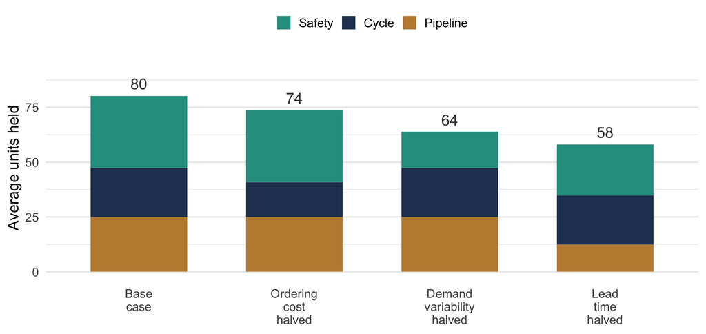

## Reading the Bars

Each bar is total stock for one item after **one lever** has been pulled, with the three components stacked.

**Halving the ordering cost** moves only the cycle component. 80 down to 74.

**Halving the variability of demand** moves only the safety component. 80 down to 64.

**Halving the lead time** moves **two of the three at once**, pipeline and safety. 80 down to 58, the largest reduction of the three, and with no loss of service.

## Why Lead Time Wins

Lead time is the only one of the three that appears in **two components**:

- directly, in the pipeline
- through the exposure window, in the safety stock

$$\overline{\mathit{IO}} = \lambda L
\qquad\text{and}\qquad
\text{safety stock} \propto \sigma\sqrt{L}$$

Lead time reduction is the most reliably **underrated** lever in inventory management.

## A Directive That Is Not Actionable

> “Reduce inventory by twenty percent.”

This is not an instruction, because it does not say **which kind**.

Each of the five responds to a different intervention. Most of those interventions take **months**.

Exactly one of them can be executed **by decree**: reducing the safety stock.

## What Happens Next Is Predictable

Faced with a target and a deadline, the only lever available **on the deadline** is the safety stock.

So that is the lever that gets pulled. Inventory falls on schedule.

The consequence arrives **one lead time later**, as stockouts.

By then it is attributed to demand, to suppliers, or to bad luck.

The mandate was met, and the service was spent to meet it.

## The Cost of Not Holding It

All of this reads as an argument that inventory is a **symptom** of problems elsewhere: long lead times, expensive setups, unpredictable demand.

That much is correct. The conclusion sometimes drawn from it, that the right target is therefore **zero**, does not follow.

Inventory is not waste. It is a **purchase**. What it buys is the ability to serve a demand from stock committed before anyone knew the demand would come.

Remove it without removing what created it, and you convert a holding cost into a **shortage cost**. Shortage costs are the ones that appear on no ledger.

## The Question Is Never Whether

The question is never *whether* to hold inventory.

It is **how much**, and **when to replenish**, given what holding costs and what not holding costs.

Every model in this course answers that pair of questions under a particular set of assumptions about demand, lead times, costs, and review.

The assumptions change from chapter to chapter.

**The question does not.**

## What We Did Today

**Inventory decouples.** Take it away without removing the separation and something stops.

**Lead time appears in two components**, which is why halving it beat the other two levers without costing any service.

**An unspecified reduction target gets paid for out of safety stock**, and the bill arrives a lead time later.

## For Next Time

**Read before next session:** *Classifying Inventory Systems*, and *The State of an Inventory System*.

Next session:

- The nine questions you ask of a system before choosing any model
- The state variables: what is on hand, on order, and owed
- Why every policy in this course triggers on **inventory position** and never on the shelf
- Little’s law, which gives three results for the price of one

Bring the five kinds with you. The classification questions next session are what tell you which kind you are looking at.

⌂ Index